# PGLS pollen size by sex system

### Fitting models

#### A. Is there an effect of sex system on pollen number? Do we see a size-number tradeoff across species (i.e. is there an effect of pollen size on number)?

model: pollen production/anther ~ pollen size + sex system + collector

```r
# fit the PGLS model:
fullA <- pgls(Log_avg_pol_anth ~ Avg_diam + Sex_sys + collector, dat=test.data, lambda="ML")
summary(fullA)
```

```
##
## Call:
## pgls(formula = Log_avg_pol_anth ~ Avg_diam + Sex_sys + collector,
##     data = test.data, lambda = "ML")
##
## Residuals:
##      Min       1Q   Median       3Q      Max
## -0.10054 -0.02324  0.01568  0.04546  0.15128
##
## Branch length transformations:
##
## kappa  [Fix]  : 1.000
## lambda [ ML]  : 0.000
##    lower bound : 0.000, p = 1
##    upper bound : 1.000, p = 0.10456
##    95.0% CI   : (NA, NA)
## delta  [Fix]  : 1.000
##
## Coefficients:
##                        Estimate Std. Error t value  Pr(>|t|)
## (Intercept)            6.767602   0.850489  7.9573 6.451e-08 ***
## Avg_diam               0.060369   0.035466  1.7022  0.102814
## Sex_syshermaphroditic -0.810690   0.692092 -1.1714  0.253984
## Sex_sysmonoecious     -1.952845   0.649407 -3.0071  0.006487 **
## collectorCS            1.574435   0.833103  1.8898  0.072027 .
## ---
## Signif. codes:  0 '***' 0.001 '**' 0.01 '*' 0.05 '.' 0.1 ' ' 1
##
## Residual standard error: 0.06677 on 22 degrees of freedom
## Multiple R-squared: 0.5033,  Adjusted R-squared: 0.413
## F-statistic: 5.573 on 4 and 22 DF,  p-value: 0.002967
```

```r
# ML lambda estimate is 0, not significantly different from 0 or 1.
anova(fullA) # sig effect of diam and sex sys
```

```
## Analysis of Variance Table
## Sequential SS for pgls: lambda = 0.00, delta = 1.00, kappa = 1.00
##
## Response: Log_avg_pol_anth
##           Df   Sum Sq  Mean Sq F value   Pr(>F)
## Avg_diam   1 0.031827 0.031827  7.1381 0.013934 *
## Sex_sys    2 0.051648 0.025824  5.7917 0.009534 **
## collector  1 0.015925 0.015925  3.5715 0.072027 .
## Residuals 22 0.098093 0.004459
## ---
## Signif. codes:  0 '***' 0.001 '**' 0.01 '*' 0.05 '.' 0.1 ' ' 1
```

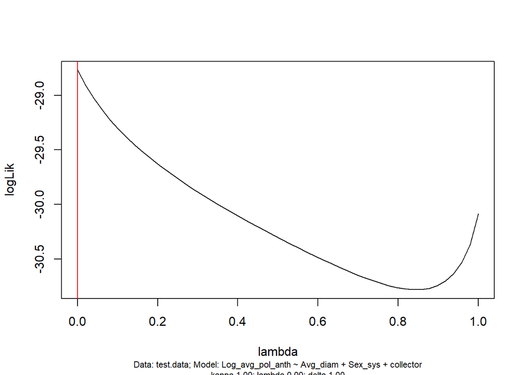

```r
plot(pgls.profile(fullA, "lambda")) # strange likelihood surface, looks like local peaks around 0 and 1...
```

```r
# Since the ML lambda wasn't significantly different from 0 or 1 and the dataset is fairly small (<30 spp), I'll run
# two analyses: an OLS model (lambda=0) and a PGLS model with lambda=1
# OLS:
modA_OLS <- lm(Log_avg_pol_anth ~ Avg_diam + Sex_sys + collector, dat=sizenum_sp)
summary(modA_OLS)
```

```
##
## Call:
## lm(formula = Log_avg_pol_anth ~ Avg_diam + Sex_sys + collector,
##     data = sizenum_sp)
##
## Residuals:
##     Min      1Q  Median      3Q     Max
## -2.0660 -0.3002  0.1249  0.4247  1.0807
##
## Coefficients:
##                       Estimate Std. Error t value Pr(>|t|)
## (Intercept)            6.76760    0.85049   7.957 6.45e-08 ***
## Avg_diam               0.06037    0.03547   1.702  0.10281
## Sex_syshermaphroditic -0.81069    0.69209  -1.171  0.25398
## Sex_sysmonoecious     -1.95285    0.64941  -3.007  0.00649 **
## collectorCS            1.57443    0.83310   1.890  0.07203 .
## ---
## Signif. codes:  0 '***' 0.001 '**' 0.01 '*' 0.05 '.' 0.1 ' ' 1
##
## Residual standard error: 0.778 on 22 degrees of freedom
## Multiple R-squared:  0.5033, Adjusted R-squared:  0.413
## F-statistic: 5.573 on 4 and 22 DF,  p-value: 0.002967
```

```r
anova(modA_OLS) # sig effect of sex system and diameter
```

```
## Analysis of Variance Table
##
## Response: Log_avg_pol_anth
##           Df  Sum Sq Mean Sq F value   Pr(>F)
## Avg_diam   1  4.3208  4.3208  7.1382 0.013933 *
## Sex_sys    2  7.0116  3.5058  5.7917 0.009534 **
## collector  1  2.1619  2.1619  3.5715 0.072027 .
## Residuals 22 13.3169  0.6053
## ---
## Signif. codes:  0 '***' 0.001 '**' 0.01 '*' 0.05 '.' 0.1 ' ' 1
```

```r
# PGLS with lambda=1:
modA_PGLS <- pgls(Log_avg_pol_anth ~ Avg_diam + Sex_sys + collector, dat=test.data, lambda=1)
summary(modA_PGLS)
```

```
##
## Call:
## pgls(formula = Log_avg_pol_anth ~ Avg_diam + Sex_sys + collector,
##     data = test.data, lambda = 1)
##
## Residuals:
##      Min       1Q   Median       3Q      Max
## -0.19977 -0.06264  0.02402  0.11604  0.34019
##
## Branch length transformations:
##
## kappa  [Fix]  : 1.000
## lambda [Fix]  : 1.000
## delta  [Fix]  : 1.000
##
## Coefficients:
##                        Estimate Std. Error t value Pr(>|t|)
## (Intercept)            7.419573   1.230559  6.0294 4.55e-06 ***
## Avg_diam               0.012783   0.036592  0.3493   0.7302
## Sex_syshermaphroditic -0.497031   1.289091 -0.3856   0.7035
## Sex_sysmonoecious     -1.243376   0.897357 -1.3856   0.1798
## collectorCS            1.993134   1.561898  1.2761   0.2152
## ---
## Signif. codes:  0 '***' 0.001 '**' 0.01 '*' 0.05 '.' 0.1 ' ' 1
##
## Residual standard error: 0.1479 on 22 degrees of freedom
## Multiple R-squared: 0.1257,  Adjusted R-squared: -0.03326
## F-statistic: 0.7908 on 4 and 22 DF,  p-value: 0.5437
```

```r
anova(modA_PGLS) # no sig effect of sex system or diameter
```

```
## Analysis of Variance Table
## Sequential SS for pgls: lambda = 1.00, delta = 1.00, kappa = 1.00
##
## Response: Log_avg_pol_anth
##           Df  Sum Sq  Mean Sq F value Pr(>F)
## Avg_diam   1 0.00114 0.001138  0.0520 0.8218
## Sex_sys    2 0.03245 0.016223  0.7413 0.4880
## collector  1 0.03564 0.035636  1.6284 0.2152
## Residuals 22 0.48144 0.021884
```

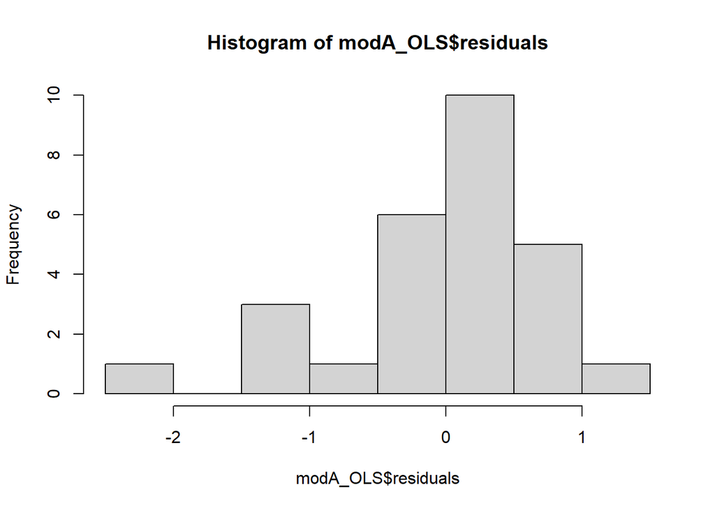

```r
### Check assumptions:
## OLS
#normality of residuals
hist(modA_OLS$residuals) #ok
```

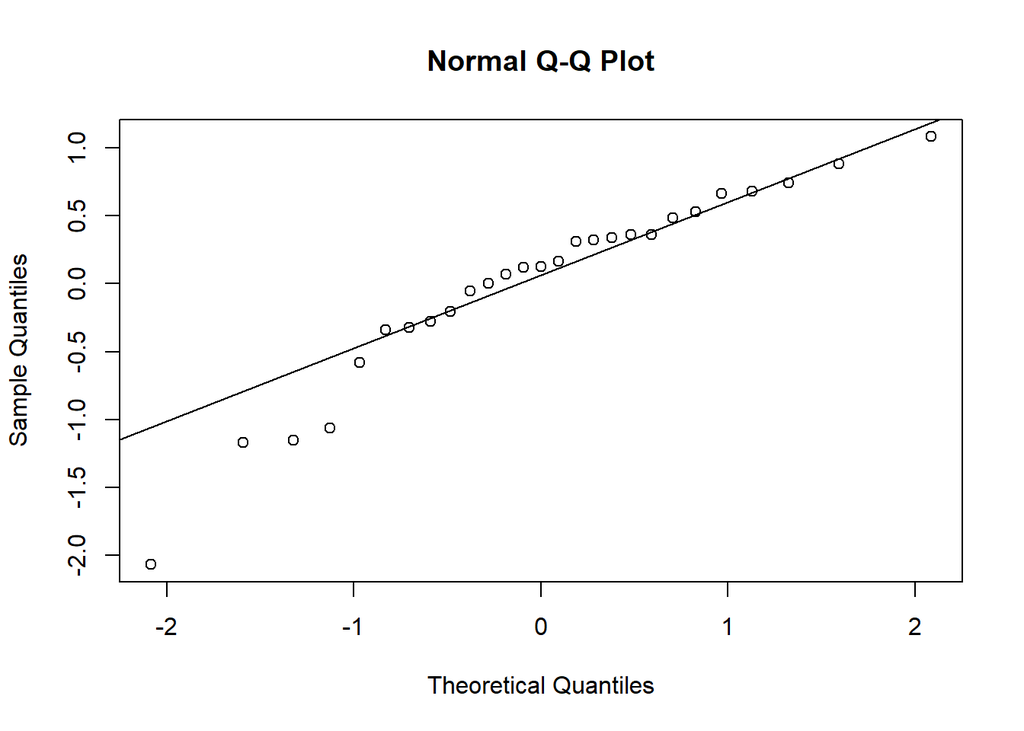

```r
qqnorm(modA_OLS$residuals)
qqline(modA_OLS$residuals) #looks okay
```

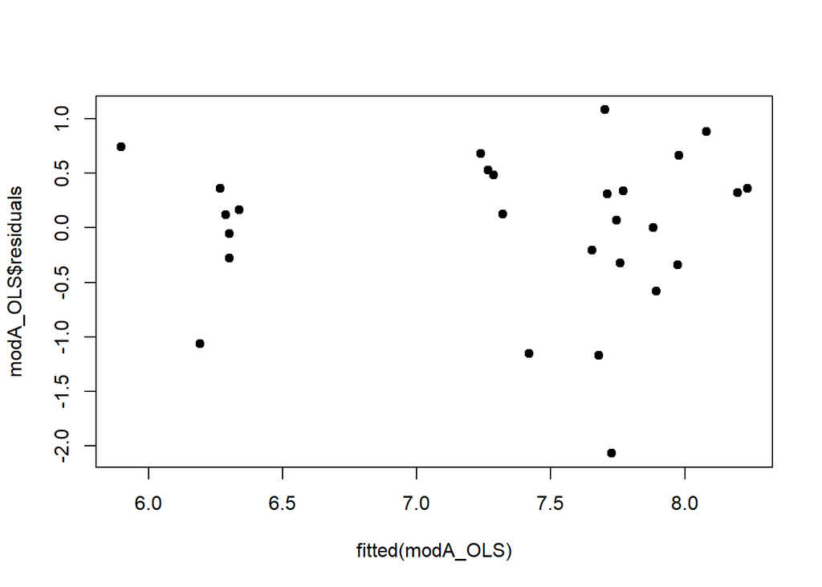

```r
#homogeneity of residuals
plot(x=fitted(modA_OLS), y=modA_OLS$residuals, pch=19)
```

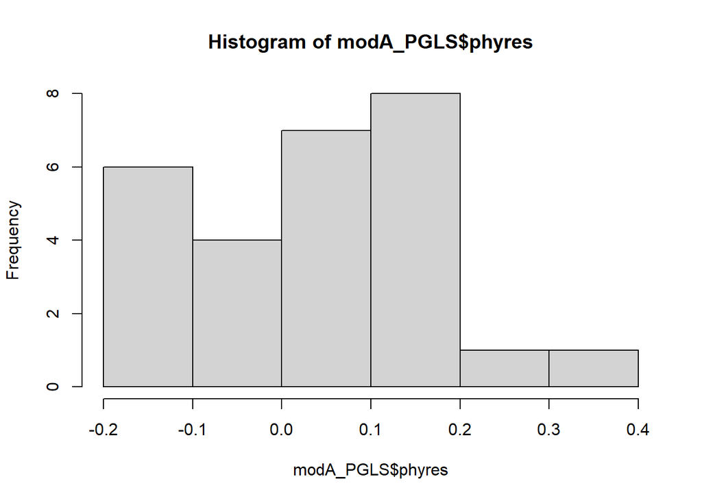

```r
##PGLS
#inspect the phylogenetic residuals for normality:
hist(modA_PGLS$phyres) #looks pretty normal
```

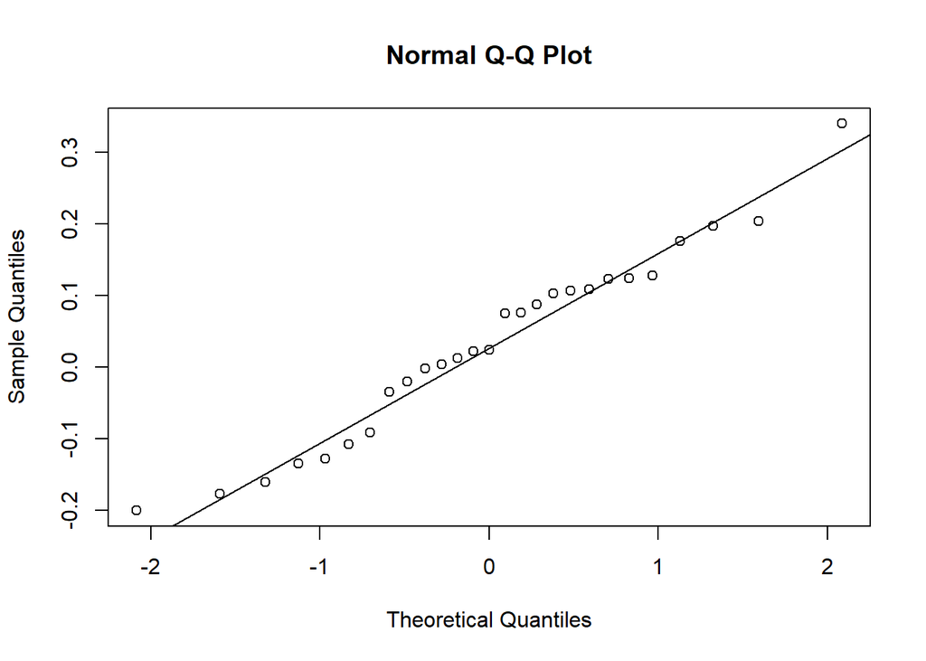

```r
qqnorm(modA_PGLS$phyres)
qqline(modA_PGLS$phyres) #looks okay...
```

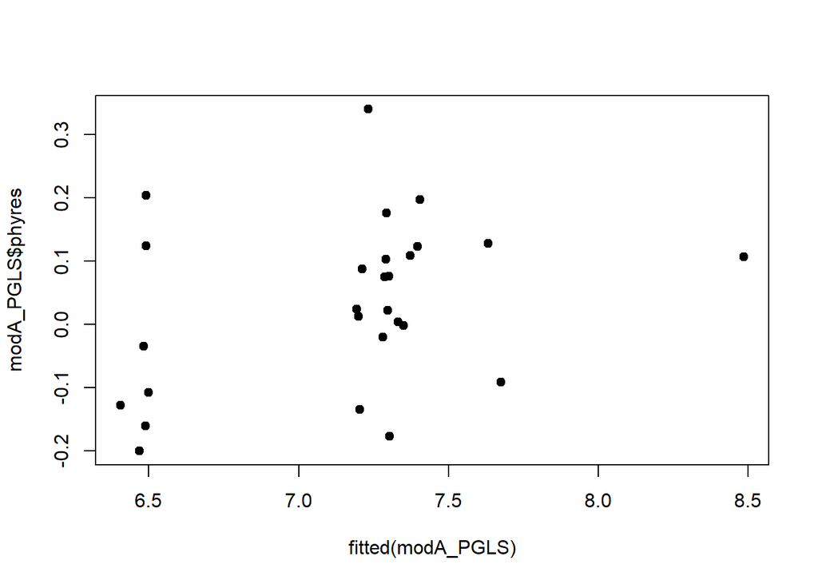

```r
#inspect phylogenetic residuals for homogeneity:
plot(x=fitted(modA_PGLS), y=modA_PGLS$phyres, pch=19)
```

```r
# only 2 dieocious species - might give them undue influence and not represent their sex system well. Also much
# more variable in hermaphroditic category.

## Mixed effects mod
# Since lambda not significantly different from 0 or 1, I'll also do an lmer OLS model with species as random effect.
# I'll use the data that's not grouped by species - sizenum
# head(sizenum)
# summary(sizenum)
# names(sizenum)
#  [1] "source"          "Sex_sys"         "Species"         "Site"            "Ind"             "Label"
#  [7] "Avg_diam"        "Sd_diam"         "N_diam"          "Avg_area"        "Avg_pol_anth"    "Sd_pol_anth"
# [13] "Anth_per_flw"    "count_method"    "Anth_per_sample" "Pol_flw"         "Sd_pol_flw"

sizenum_filt <- sizenum %>%
  # Check all have both size and number measures
  filter(!is.na(Avg_diam) & !is.na(Avg_pol_anth)) %>%
  filter(Species %in% sizenum_sp$Species) %>%
  # Make new column, collector
  mutate(collector = ifelse(source == "CS2021", "CS", "JF")) %>%
  # Create Log pol anth column
  mutate(Log_avg_pol_anth = log(Avg_pol_anth))

prodsize_mixmod <- lmer(Log_avg_pol_anth ~ Avg_diam + Sex_sys + collector + (1|Species), data = sizenum_filt)
summary(prodsize_mixmod)
```

```
## Linear mixed model fit by REML. t-tests use Satterthwaite's method [
## lmerModLmerTest]
## Formula: Log_avg_pol_anth ~ Avg_diam + Sex_sys + collector + (1 | Species)
##    Data: sizenum_filt
##
## REML criterion at convergence: 786.9
##
## Scaled residuals:
##     Min      1Q  Median      3Q     Max
## -7.4385 -0.3579  0.1453  0.5500  2.8291
##
## Random effects:
##  Groups   Name        Variance Std.Dev.
##  Species  (Intercept) 0.6358   0.7974
##  Residual             0.2069   0.4549
## Number of obs: 542, groups:  Species, 25
##
## Fixed effects:
##                         Estimate Std. Error         df t value Pr(>|t|)
## (Intercept)            10.198191   1.065987  23.035541   9.567 1.72e-09 ***
## Avg_diam               -0.037025   0.013725 485.365517  -2.698  0.00723 **
## Sex_syshermaphroditic  -0.006068   0.619120  22.127006  -0.010  0.99227
## Sex_sysmonoecious      -1.429494   0.647968  20.776232  -2.206  0.03878 *
## collectorJF            -1.716433   0.861074  20.546788  -1.993  0.05967 .
## ---
## Signif. codes:  0 '***' 0.001 '**' 0.01 '*' 0.05 '.' 0.1 ' ' 1
##
## Correlation of Fixed Effects:
##             (Intr) Avg_dm Sx_sysh Sx_sysm
## Avg_diam    -0.253
## Sx_syshrmph -0.435 -0.212
## Sex_sysmncs -0.574 -0.108  0.827
## collectorJF -0.813  0.021 -0.005   0.163
```

```r
anova(prodsize_mixmod) # sig effects of diam and sex system
```

```
## Type III Analysis of Variance Table with Satterthwaite's method
##           Sum Sq Mean Sq NumDF  DenDF F value   Pr(>F)
## Avg_diam  1.5057 1.50572     1 485.37  7.2771 0.007227 **
## Sex_sys   3.1643 1.58215     2  21.56  7.6464 0.003091 **
## collector 0.8222 0.82217     1  20.55  3.9735 0.059668 .
## ---
## Signif. codes:  0 '***' 0.001 '**' 0.01 '*' 0.05 '.' 0.1 ' ' 1
```

```r
emmeans(prodsize_mixmod , ~Sex_sys)
```

```
##  Sex_sys        emmean    SE   df lower.CL upper.CL
##  dioecious        8.38 0.719 21.2     6.89     9.88
##  hermaphroditic   8.38 0.480 21.0     7.38     9.38
##  monoecious       6.96 0.431 20.8     6.06     7.85
##
## Results are averaged over the levels of: collector
## Degrees-of-freedom method: kenward-roger
## Confidence level used: 0.95
```

```r
emmeans(prodsize_mixmod , list(pairwise ~ Sex_sys), adjust = "tukey")
```

```
## $`emmeans of Sex_sys`
##  Sex_sys        emmean    SE   df lower.CL upper.CL
##  dioecious        8.38 0.719 21.2     6.89     9.88
##  hermaphroditic   8.38 0.480 21.0     7.38     9.38
##  monoecious       6.96 0.431 20.8     6.06     7.85
##
## Results are averaged over the levels of: collector
## Degrees-of-freedom method: kenward-roger
## Confidence level used: 0.95
##
## $`pairwise differences of Sex_sys`
##  1                           estimate    SE   df t.ratio p.value
##  dioecious - hermaphroditic   0.00607 0.619 22.3   0.010  0.9999
##  dioecious - monoecious       1.42949 0.648 21.0   2.206  0.0934
##  hermaphroditic - monoecious  1.42343 0.374 21.7   3.809  0.0027
##
## Results are averaged over the levels of: collector
## Degrees-of-freedom method: kenward-roger
## P value adjustment: tukey method for comparing a family of 3 estimates
```

[figure not shown]

```r
# plot(emmeans(prodsize_mixmod , ~Sex_sys))
em_prodsize <- emmeans(prodsize_mixmod , ~Sex_sys) %>%  as.data.frame()
# Plot estimated marginal means for pollen production:
ggplot(data=em_prodsize, aes(x=Sex_sys, y=emmean)) +
  geom_point(size=3) +
  geom_errorbar(aes(ymin=lower.CL, ymax=upper.CL), width=0.1) +
  # Add letters corresponding to Tukey's HSD
  geom_text(aes(x=1, y=10.1), label="AB") +
  geom_text(aes(x=2, y=9.6), label="A") +
  geom_text(aes(x=3, y=8.1), label="B") +
  scale_y_continuous(name="Pollen production per anther",
                     breaks = log(c(250, 500,1000, 2500, 5000, 10000, 20000)),
                     labels = c(250, 500,1000, 2500, 5000, 10000, 20000),
                     limits = c(log(250), NA)) +
  scale_x_discrete(name = "Sex system", labels = c("Dioecious", "Monoecious", "Hermaphroditic")) +
  theme_cs()
```

#### B. Does pollen size vary in wind-pollinated species according to their sex system? Specifically, do dioecious species make smaller pollen (to facilitate long-distance dispersal)?

model: pollen size ~ sex system + collector

```r
#now fit the PGLS model:
# fullB <- pgls(Avg_diam ~ Sex_sys + collector, dat=test.data, lambda="ML")
# summary(fullB)
# anova(fullB)
#I'll remove collector from model so that I can ML estimate lambda - was meant to be a control predictor but it doesn't have a significant effect on response in any of the subsequent models anyway

modB <- pgls(Avg_diam ~ Sex_sys, dat=test.data, lambda="ML")
summary(modB)
```

```
##
## Call:
## pgls(formula = Avg_diam ~ Sex_sys, data = test.data, lambda = "ML")
##
## Residuals:
##      Min       1Q   Median       3Q      Max
## -1.33206 -0.34877 -0.03412  0.19087  0.93356
##
## Branch length transformations:
##
## kappa  [Fix]  : 1.000
## lambda [ ML]  : 0.800
##    lower bound : 0.000, p = 0.61514
##    upper bound : 1.000, p = 0.25258
##    95.0% CI   : (NA, NA)
## delta  [Fix]  : 1.000
##
## Coefficients:
##                       Estimate Std. Error t value  Pr(>|t|)
## (Intercept)            18.3693     4.1135  4.4656 0.0001617 ***
## Sex_syshermaphroditic   6.7866     4.8462  1.4004 0.1741936
## Sex_sysmonoecious       4.3682     4.1248  1.0590 0.3001401
## ---
## Signif. codes:  0 '***' 0.001 '**' 0.01 '*' 0.05 '.' 0.1 ' ' 1
##
## Residual standard error: 0.5471 on 24 degrees of freedom
## Multiple R-squared: 0.07627, Adjusted R-squared: -0.0007053
## F-statistic: 0.9908 on 2 and 24 DF,  p-value: 0.3859
```

```r
# estimated lambda is 0.793, but not significantly different from 0 or 1
anova(modB) # no sig effect of sex system
```

```
## Analysis of Variance Table
## Sequential SS for pgls: lambda = 0.80, delta = 1.00, kappa = 1.00
##
## Response: Avg_diam
##           Df Sum Sq Mean Sq F value Pr(>F)
## Sex_sys    2 0.5930 0.29652  0.9908 0.3859
## Residuals 24 7.1824 0.29927
```

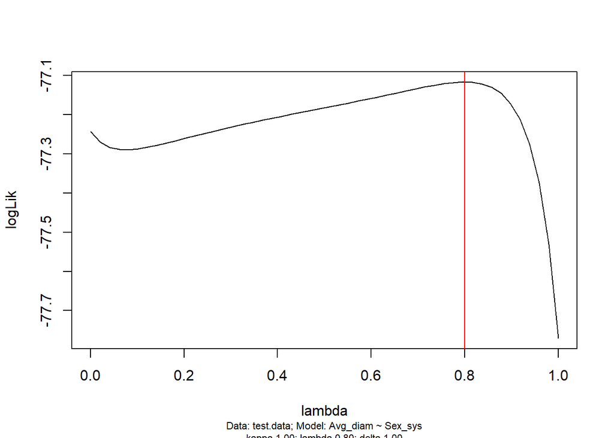

```r
plot(pgls.profile(modB, "lambda")) # pretty flat likelihood surface, small local peak near 0, another peak at what must be 0.793
```

```r
# Since the ML lambda wasn't significantly different from 0 or 1 and the dataset is fairly small (<30 spp), I'll run
# two analyses: an OLS model (lambda=0) and a PGLS model with lambda=1

modB_OLS <- lm(Avg_diam ~ Sex_sys, dat=sizenum_sp)
summary(modB_OLS)
```

```
##
## Call:
## lm(formula = Avg_diam ~ Sex_sys, data = sizenum_sp)
##
## Residuals:
##    Min     1Q Median     3Q    Max
## -7.621 -1.223  0.508  1.423  8.844
##
## Coefficients:
##                       Estimate Std. Error t value Pr(>|t|)
## (Intercept)             18.288      3.172   5.766 6.07e-06 ***
## Sex_syshermaphroditic   10.577      3.353   3.155  0.00429 **
## Sex_sysmonoecious        5.259      3.546   1.483  0.15106
## ---
## Signif. codes:  0 '***' 0.001 '**' 0.01 '*' 0.05 '.' 0.1 ' ' 1
##
## Residual standard error: 4.485 on 24 degrees of freedom
## Multiple R-squared:  0.383,  Adjusted R-squared:  0.3316
## F-statistic:  7.45 on 2 and 24 DF,  p-value: 0.003042
```

```r
anova(modB_OLS) # sig effect of sex system
```

```
## Analysis of Variance Table
##
## Response: Avg_diam
##           Df Sum Sq Mean Sq F value   Pr(>F)
## Sex_sys    2 299.75 149.876  7.4501 0.003042 **
## Residuals 24 482.81  20.117
## ---
## Signif. codes:  0 '***' 0.001 '**' 0.01 '*' 0.05 '.' 0.1 ' ' 1
```

```r
modB_PGLS <- pgls(Avg_diam ~ Sex_sys, dat=test.data, lambda=1)
summary(modB_PGLS)
```

```
##
## Call:
## pgls(formula = Avg_diam ~ Sex_sys, data = test.data, lambda = 1)
##
## Residuals:
##      Min       1Q   Median       3Q      Max
## -1.53344 -0.29314  0.00199  0.25891  1.46484
##
## Branch length transformations:
##
## kappa  [Fix]  : 1.000
## lambda [Fix]  : 1.000
## delta  [Fix]  : 1.000
##
## Coefficients:
##                       Estimate Std. Error t value Pr(>|t|)
## (Intercept)            18.3984     5.6942  3.2311 0.003562 **
## Sex_syshermaphroditic   6.1392     6.5114  0.9429 0.355152
## Sex_sysmonoecious       4.2682     4.8720  0.8761 0.389679
## ---
## Signif. codes:  0 '***' 0.001 '**' 0.01 '*' 0.05 '.' 0.1 ' ' 1
##
## Residual standard error: 0.8283 on 24 degrees of freedom
## Multiple R-squared: 0.04108, Adjusted R-squared: -0.03883
## F-statistic: 0.5141 on 2 and 24 DF,  p-value: 0.6045
```

```r
anova(modB_PGLS) # no sig effect of sex system
```

```
## Analysis of Variance Table
## Sequential SS for pgls: lambda = 1.00, delta = 1.00, kappa = 1.00
##
## Response: Avg_diam
##           Df  Sum Sq Mean Sq F value Pr(>F)
## Sex_sys    2  0.7053 0.35265  0.5141 0.6045
## Residuals 24 16.4640 0.68600
```

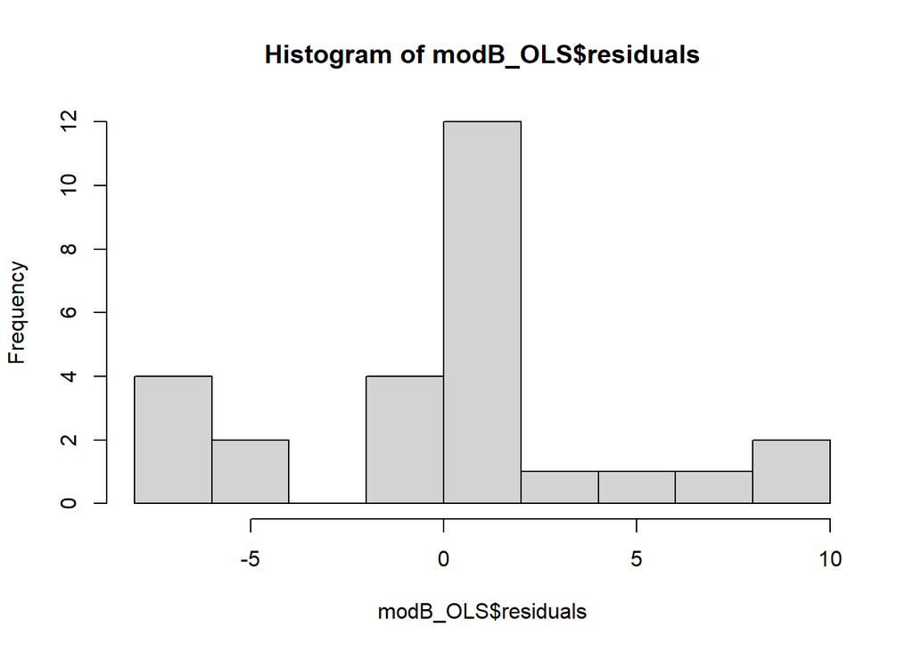

```r
### Check assumptions:
## OLS
#normality of residuals
hist(modB_OLS$residuals) #looks narrow but ok
```

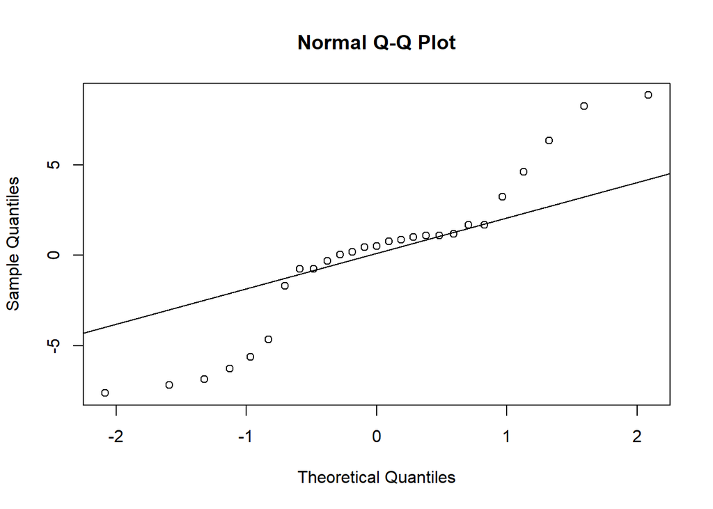

```r
qqnorm(modB_OLS$residuals)
qqline(modB_OLS$residuals) #looks okay?
```

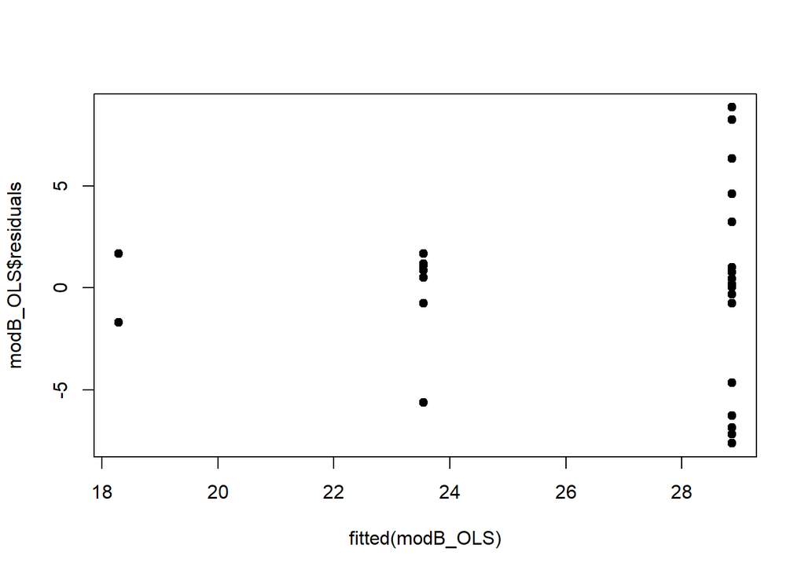

```r
#homogeneity of residuals
plot(x=fitted(modB_OLS), y=modB_OLS$residuals, pch=19) #potentially an issue here with so few dioecious species. The two dioecious species have much lower fitted values, appear to be less variable (but hard to say because there's only 2!)
```

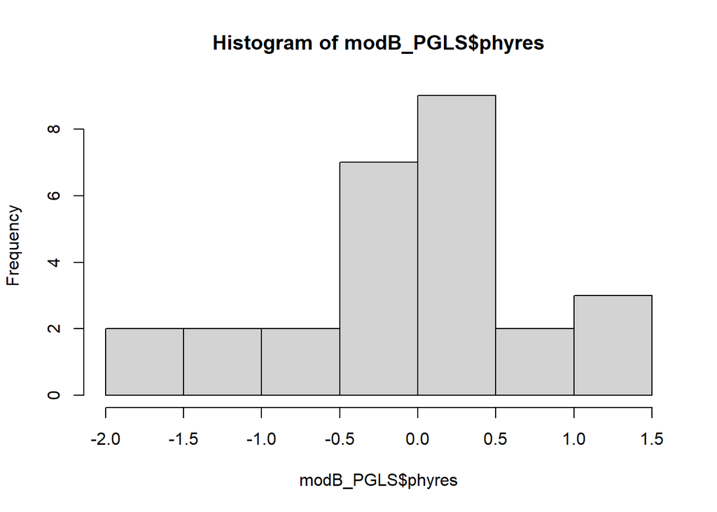

```r
##PGLS
#inspect the phylogenetic residuals for normality:
hist(modB_PGLS$phyres) #looks pretty normal
```

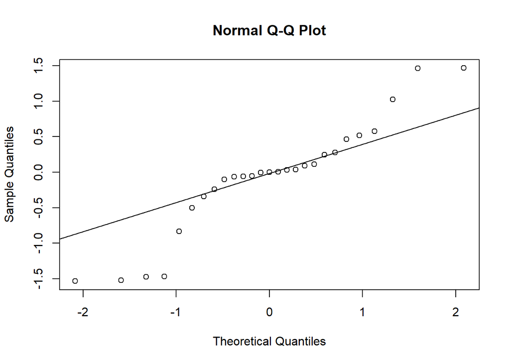

```r
qqnorm(modB_PGLS$phyres)
qqline(modB_PGLS$phyres) #looks okay...
```

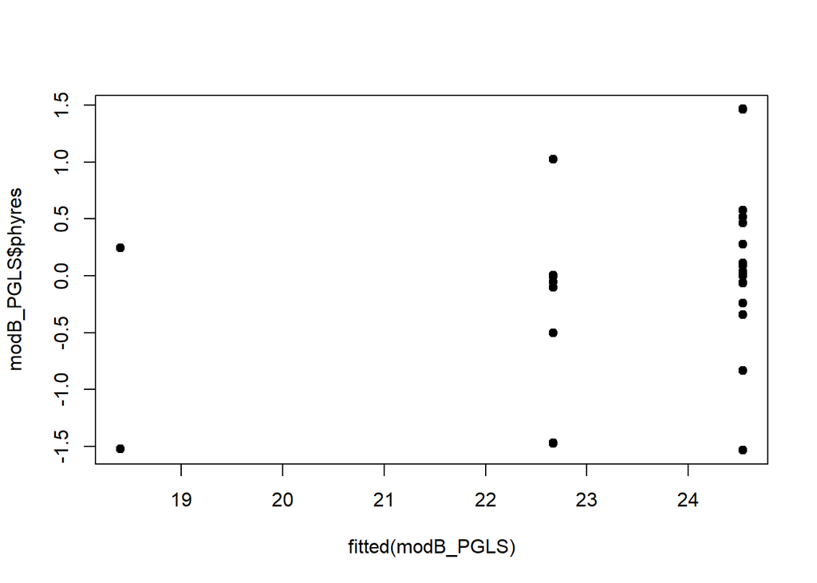

```r
#inspect phylogenetic residuals for homogeneity:
plot(x=fitted(modB_PGLS), y=modB_PGLS$phyres, pch=19)
```

```r
# only 2 dieocious species - might give them undue influence and not represent their sex system well. Also much
# more variable in hermaphroditic category.
```

Since lambda was not significantly different from 0 or 1, I’ll also do a linear mixed effects model on pollen size by sex system with species as random effect.

```r
## Mixed effects mod
# I'll use the data that's not grouped by species - sizenum
sizenum_filt <- sizenum %>%
  # Check all have both size and number measures
  filter(!is.na(Avg_diam) & !is.na(Avg_pol_anth)) %>%
  filter(Species %in% sizenum_sp$Species) %>%
  # Make new column, collector
  mutate(collector = ifelse(source == "CS2021", "CS", "JF")) %>%
  # Arrange species in order of sex system and alphabetically by species
  mutate(Sex_sys = as.character(Sex_sys),
         Sex_sys = factor(Sex_sys, levels=c("dioecious", "monoecious", "hermaphroditic")) ) %>%
  arrange(desc(Sex_sys), desc(Species)) %>%
  mutate(Species =  factor(Species, levels = unique(Species), ordered = T))

size_mixmod <- lmer(Avg_diam ~ Sex_sys + (1|Species), data = sizenum_filt)
summary(size_mixmod)
```

```
## Linear mixed model fit by REML. t-tests use Satterthwaite's method [
## lmerModLmerTest]
## Formula: Avg_diam ~ Sex_sys + (1 | Species)
##    Data: sizenum_filt
##
## REML criterion at convergence: 2003
##
## Scaled residuals:
##     Min      1Q  Median      3Q     Max
## -4.2272 -0.4721 -0.0004  0.5722  5.0400
##
## Random effects:
##  Groups   Name        Variance Std.Dev.
##  Species  (Intercept) 15.788   3.973
##  Residual              1.909   1.382
## Number of obs: 542, groups:  Species, 25
##
## Fixed effects:
##                       Estimate Std. Error     df t value Pr(>|t|)
## (Intercept)             18.287      2.817 21.944   6.491 1.59e-06 ***
## Sex_sysmonoecious        5.259      3.150 21.951   1.669  0.10922
## Sex_syshermaphroditic    9.568      3.000 21.963   3.189  0.00424 **
## ---
## Signif. codes:  0 '***' 0.001 '**' 0.01 '*' 0.05 '.' 0.1 ' ' 1
##
## Correlation of Fixed Effects:
##             (Intr) Sx_sysm
## Sex_sysmncs -0.894
## Sx_syshrmph -0.939  0.840
```

```r
anova(size_mixmod)
```

```
## Type III Analysis of Variance Table with Satterthwaite's method
##         Sum Sq Mean Sq NumDF  DenDF F value   Pr(>F)
## Sex_sys 26.023  13.012     2 21.989  6.8142 0.004979 **
## ---
## Signif. codes:  0 '***' 0.001 '**' 0.01 '*' 0.05 '.' 0.1 ' ' 1
```

From the mixed effects model, sex system has a significant effect on pollen size. I’ll use emmeans to run a Tukey’s HSD to determine which groups are significantly different from each other and the direction of the difference(s).

```r
emmeans(size_mixmod , ~Sex_sys)
```

```
##  Sex_sys        emmean   SE   df lower.CL upper.CL
##  dioecious        18.3 2.82 21.9     12.4     24.1
##  monoecious       23.5 1.41 21.9     20.6     26.5
##  hermaphroditic   27.9 1.03 22.1     25.7     30.0
##
## Degrees-of-freedom method: kenward-roger
## Confidence level used: 0.95
```

```r
emmeans(size_mixmod , list(pairwise ~ Sex_sys), adjust = "tukey")
```

```
## $`emmeans of Sex_sys`
##  Sex_sys        emmean   SE   df lower.CL upper.CL
##  dioecious        18.3 2.82 21.9     12.4     24.1
##  monoecious       23.5 1.41 21.9     20.6     26.5
##  hermaphroditic   27.9 1.03 22.1     25.7     30.0
##
## Degrees-of-freedom method: kenward-roger
## Confidence level used: 0.95
##
## $`pairwise differences of Sex_sys`
##  1                           estimate   SE   df t.ratio p.value
##  dioecious - monoecious         -5.26 3.15 21.9  -1.669  0.2392
##  dioecious - hermaphroditic     -9.57 3.00 21.9  -3.189  0.0114
##  monoecious - hermaphroditic    -4.31 1.75 22.0  -2.468  0.0548
##
## Degrees-of-freedom method: kenward-roger
## P value adjustment: tukey method for comparing a family of 3 estimates
```

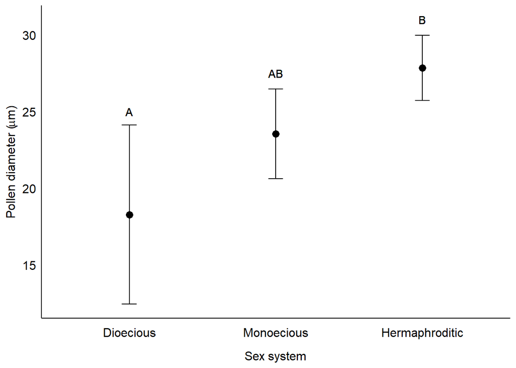

```r
# plot(emmeans(size_mixmod , ~Sex_sys))
em_size <- emmeans(size_mixmod , ~Sex_sys) %>%  as.data.frame()
# Plot estimated marginal means:
ggplot(data=em_size, aes(x=Sex_sys, y=emmean)) +
  geom_point(size=3) +
  geom_errorbar(aes(ymin=lower.CL, ymax=upper.CL), width=0.1) +
  # Add letters corresponding to Tukey's HSD
  geom_text(aes(x=1, y=25), label="A") +
  geom_text(aes(x=2, y=27.5), label="AB") +
  geom_text(aes(x=3, y=31), label="B") +
  scale_y_continuous(name = expression("Pollen diameter ("*mu*"m)")) +
  scale_x_discrete(name = "Sex system", labels = c("Dioecious", "Monoecious", "Hermaphroditic")) +
  theme_cs()
```

In the mixed effects model, sex system does have a significant effect on size. A Tukey’s HSD test shows that dieocious speces have significantly smaller pollen than hermaphroditic species but not monoecious species, and monoecious species don’t have significantly smaller pollen than hermaphroditic species.